# Human Genome Analysis Lab 9 : Working with COVID-19 reporting data

*I recognize, and fully understand, that this data maybe emotionally difficult to work. My intention is to make these lab relevant, allowing you to gather your own insights directly from new visualizations of the data. Please let me know if you would rather not work with the data.*

## Learning Objectives

- Understanding the sources of SARS-CoV-2 incidence reports
- Accessing data remotely
- Learn the difference between wide and long table formats
- Mapping data using latitude and longitude coordinates

## Visualizing COVID-19 cases, deaths and recoveries

The virus has been recently renamed based on phylogenetic analysis (more on this next week) severe acute respiratory syndrome coronavirus 2 (SARS-CoV-2). The disease caused by the virus is coronavirus disease (COVID-19). In this lab we will work with reporting data on COVID-19 cases, deaths and recoveries.

### Introduction to JHU case tracking data

Researchers (Ensheng Dong, Hongru Du, Lauren Gardner) at John Hopkins University developed an [interactive dashboard](https://www.arcgis.com/apps/opsdashboard/index.html#/bda7594740fd40299423467b48e9ecf6) to visual data and track reported cases of coronavirus disease 2019 (SARS-CoV-2) in real time. The underlying data is collated from the following sources and updated several times a day.

[World Health Organization (WHO)](https://www.who.int/) | [DXY.cn. Pneumonia. 2020](http://3g.dxy.cn/newh5/view/pneumonia) | [BNO News](https://bnonews.com/index.php/2020/02/the-latest-coronavirus-cases/) | [National Health Commission of the People’s Republic of China (NHC)](http://www.nhc.gov.cn/xcs/yqtb/list_gzbd.shtml) | [China CDC (CCDC)](http://weekly.chinacdc.cn/news/TrackingtheEpidemic.htm) | [Hong Kong Department of Health](https://www.chp.gov.hk/en/features/102465.html) | [Macau Government](https://www.ssm.gov.mo/portal/) | [Taiwan CDC](https://sites.google.com/cdc.gov.tw/2019ncov/taiwan?authuser=0) | [US CDC](https://www.cdc.gov/coronavirus/2019-ncov/index.html) | [Government of Canada](https://www.canada.ca/en/public-health/services/diseases/coronavirus.html) | [Australia Government Department of Health](https://www.health.gov.au/news/coronavirus-update-at-a-glance) | [European Centre for Disease Prevention and Control (ECDC)](https://www.ecdc.europa.eu/en/geographical-distribution-2019-ncov-cases) | [Ministry of Health Singapore (MOH)](https://www.moh.gov.sg/covid-19) | [Italy Ministry of Health](http://www.salute.gov.it/nuovocoronavirus) | [1Point3Arces](https://coronavirus.1point3acres.com/en) | [WorldoMeters](https://www.worldometers.info/coronavirus/)

- It is important to understand that this data is only as accurate as the reporting and many cases of the disease go unreported because of a lack of testing. This some countries may have have confirmed cases because of more comprehensive testing. Thus, the reporting data represent a minimum number of cases. See recent posts and an article by UMass statistian [Prof. Nick Reich](https://twitter.com/reichlab)

### JHU’s Github repo

JHU researchers make data that goes into the [dashboard](https://www.arcgis.com/apps/opsdashboard/index.html#/bda7594740fd40299423467b48e9ecf6) available on [Github repo for Novel Coronavirus (COVID-19) Cases](https://github.com/CSSEGISandData/COVID-19). In this lab we will work with this data.

You could start by creating a new Rproj and cloning the JHU repo as you did in Lab 6. However, we will not need all this data and it is easier to access the individual files directly as some are updated daily

Let’s take a look at the files and the structure of data in the files.

- csse_covid_19_data
  - csse_covid_19_daily_reports
    - 03-11-2020.csv

Open up the file to look at the structure

The file contains the columns

Province/State Country/Region Last Update Confirmed Deaths Recovered Latitude Longitude

It is important to note that for some countries there is only one row, while for others (e.g. China and US) there are multiple rows representing different provinces or states. Thus, we will need to sum these rows to get a total count for the US and China when we make graphs. From experience in making this tutorial I know the Column names with **/** will cause errors in ggplot ().

Next look at the time series data which is a complilation of the daily reports for each reporting type (Confirmed, Deaths, Recovered)

- csse_covid_19_data
  - csse_covid_19_time_series
    - time_series_covid19_confirmed_global.csv

Province/State Country/Region Lat Long 1/22/20 1/23/20 1/24/20…

This data is what is called wide format, where values of the variable being observed (Confirmed cases) are spread out across columns (Here: columns for each day). Another way of describing this is that there is more than one measurement per row. This wide format works well for data entry and sometimes works well for analysis but can be cumbersome when using R. The **tidyr** package allows us to quickly switch between wide format and what is called long format where there is only 1 column for the cases.

### Making a graphs from the daily reports

We are going to work with the data using **tidyverse** functions and use a the library **lubridate** for reformatting the dates

```r
library(tidyverse)
library(lubridate)
```

1. Go to the file you want to download.
2. Click it to view the contents within the GitHub UI.
3. In the top right, right click the Raw button.
4. Save as… or copy the url

Below I have used the url so that it will get the most current version. This method also loads the file into directly in R (memory) and doesn’t save it on your computer.

```r
report_05_06_2020 <-   read_csv(url("https://raw.githubusercontent.com/CSSEGISandData/COVID-19/master/csse_covid_19_data/csse_covid_19_daily_reports/05-06-2020.csv"))
```

Check the table properties to make sure the data imported as we expected

```r
head(report_05_06_2020)
```

```
## # A tibble: 6 x 12
##    FIPS Admin2 Province_State Country_Region Last_Update           Lat  Long_
##   <dbl> <chr>  <chr>          <chr>          <dttm>              <dbl>  <dbl>
## 1 45001 Abbev~ South Carolina US             2020-05-07 02:32:28  34.2  -82.5
## 2 22001 Acadia Louisiana      US             2020-05-07 02:32:28  30.3  -92.4
## 3 51001 Accom~ Virginia       US             2020-05-07 02:32:28  37.8  -75.6
## 4 16001 Ada    Idaho          US             2020-05-07 02:32:28  43.5 -116.
## 5 19001 Adair  Iowa           US             2020-05-07 02:32:28  41.3  -94.5
## 6 21001 Adair  Kentucky       US             2020-05-07 02:32:28  37.1  -85.3
## # ... with 5 more variables: Confirmed <dbl>, Deaths <dbl>, Recovered <dbl>,
## #   Active <dbl>, Combined_Key <chr>
```

```r
str(report_05_06_2020)
```

```
## Classes 'spec_tbl_df', 'tbl_df', 'tbl' and 'data.frame': 3216 obs. of  12 variables:
##  $ FIPS          : num  45001 22001 51001 16001 19001 ...
##  $ Admin2        : chr  "Abbeville" "Acadia" "Accomack" "Ada" ...
##  $ Province_State: chr  "South Carolina" "Louisiana" "Virginia" "Idaho" ...
##  $ Country_Region: chr  "US" "US" "US" "US" ...
##  $ Last_Update   : POSIXct, format: "2020-05-07 02:32:28" "2020-05-07 02:32:28" ...
##  $ Lat           : num  34.2 30.3 37.8 43.5 41.3 ...
##  $ Long_         : num  -82.5 -92.4 -75.6 -116.2 -94.5 ...
##  $ Confirmed     : num  33 140 429 717 3 ...
##  $ Deaths        : num  0 10 7 19 0 13 0 3 75 0 ...
##  $ Recovered     : num  0 0 0 0 0 0 0 0 0 0 ...
##  $ Active        : num  33 130 422 698 3 ...
##  $ Combined_Key  : chr  "Abbeville, South Carolina, US" "Acadia, Louisiana, US" "Accomack, Virginia, US" "Ada, Idaho, US" ...
##  - attr(*, "spec")=
##   .. cols(
##   ..   FIPS = col_double(),
##   ..   Admin2 = col_character(),
##   ..   Province_State = col_character(),
##   ..   Country_Region = col_character(),
##   ..   Last_Update = col_datetime(format = ""),
##   ..   Lat = col_double(),
##   ..   Long_ = col_double(),
##   ..   Confirmed = col_double(),
##   ..   Deaths = col_double(),
##   ..   Recovered = col_double(),
##   ..   Active = col_double(),
##   ..   Combined_Key = col_character()
##   .. )
```

- Note that data from older reports is in a different format than the new format just release yesterday.

```r
report_03_23_2020 <-   read_csv(url("https://raw.githubusercontent.com/CSSEGISandData/COVID-19/master/csse_covid_19_data/csse_covid_19_daily_reports/03-23-2020.csv"))
```

```r
head(report_03_23_2020)
```

```
## # A tibble: 6 x 12
##   FIPS  Admin2 Province_State Country_Region Last_Update           Lat  Long_
##   <chr> <chr>  <chr>          <chr>          <dttm>              <dbl>  <dbl>
## 1 45001 Abbev~ South Carolina US             2020-03-23 23:19:34  34.2  -82.5
## 2 22001 Acadia Louisiana      US             2020-03-23 23:19:34  30.3  -92.4
## 3 51001 Accom~ Virginia       US             2020-03-23 23:19:34  37.8  -75.6
## 4 16001 Ada    Idaho          US             2020-03-23 23:19:34  43.5 -116.
## 5 19001 Adair  Iowa           US             2020-03-23 23:19:34  41.3  -94.5
## 6 21001 Adair  Kentucky       US             2020-03-23 23:19:34  37.1  -85.3
## # ... with 5 more variables: Confirmed <dbl>, Deaths <dbl>, Recovered <dbl>,
## #   Active <dbl>, Combined_Key <chr>
```

```r
str(report_03_23_2020)
```

```
## Classes 'spec_tbl_df', 'tbl_df', 'tbl' and 'data.frame': 3413 obs. of  12 variables:
##  $ FIPS          : chr  "45001" "22001" "51001" "16001" ...
##  $ Admin2        : chr  "Abbeville" "Acadia" "Accomack" "Ada" ...
##  $ Province_State: chr  "South Carolina" "Louisiana" "Virginia" "Idaho" ...
##  $ Country_Region: chr  "US" "US" "US" "US" ...
##  $ Last_Update   : POSIXct, format: "2020-03-23 23:19:34" "2020-03-23 23:19:34" ...
##  $ Lat           : num  34.2 30.3 37.8 43.5 41.3 ...
##  $ Long_         : num  -82.5 -92.4 -75.6 -116.2 -94.5 ...
##  $ Confirmed     : num  1 1 1 13 1 0 2 0 18 0 ...
##  $ Deaths        : num  0 0 0 0 0 0 0 0 0 0 ...
##  $ Recovered     : num  0 0 0 0 0 0 0 0 0 0 ...
##  $ Active        : num  0 0 0 0 0 0 0 0 0 0 ...
##  $ Combined_Key  : chr  "Abbeville, South Carolina, US" "Acadia, Louisiana, US" "Accomack, Virginia, US" "Ada, Idaho, US" ...
##  - attr(*, "spec")=
##   .. cols(
##   ..   FIPS = col_character(),
##   ..   Admin2 = col_character(),
##   ..   Province_State = col_character(),
##   ..   Country_Region = col_character(),
##   ..   Last_Update = col_datetime(format = ""),
##   ..   Lat = col_double(),
##   ..   Long_ = col_double(),
##   ..   Confirmed = col_double(),
##   ..   Deaths = col_double(),
##   ..   Recovered = col_double(),
##   ..   Active = col_double(),
##   ..   Combined_Key = col_character()
##   .. )
```

- Once change is the column titles, so that we no longer required to **rename** . Note the addition of new columns to work with including county “Admin2” level information within a state. You will need to use summarize to get state or country counts.

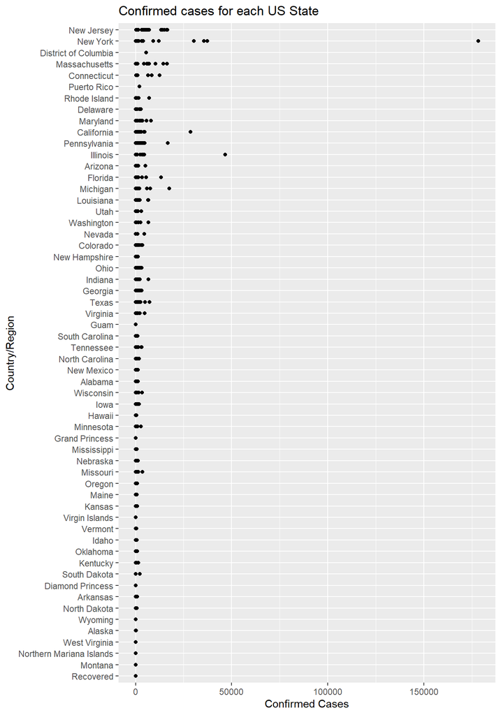

```r
report_05_06_2020 %>%
  filter (Country_Region == "US") %>%
  ggplot(aes(x = Confirmed,  y = reorder(Province_State, Confirmed))) +
    geom_point() +
    ggtitle("Confirmed cases for each US State") +
    ylab("Country/Region") +
    xlab("Confirmed Cases")
```

If we try to graph by Country_Region there are entries that have the same character (e.g. China and US) so we need to summarise the data we are interested in graphing

```r
report_05_06_2020 %>%
  group_by(Country_Region) %>%
  summarise(Deaths = sum(Deaths)) %>%
  arrange(desc(Deaths))
```

```
## # A tibble: 187 x 2
##    Country_Region Deaths
##    <chr>           <dbl>
##  1 US              73431
##  2 United Kingdom  30150
##  3 Italy           29684
##  4 Spain           25857
##  5 France          25812
##  6 Brazil           8588
##  7 Belgium          8339
##  8 Germany          7275
##  9 Iran             6418
## 10 Netherlands      5221
## # ... with 177 more rows
```

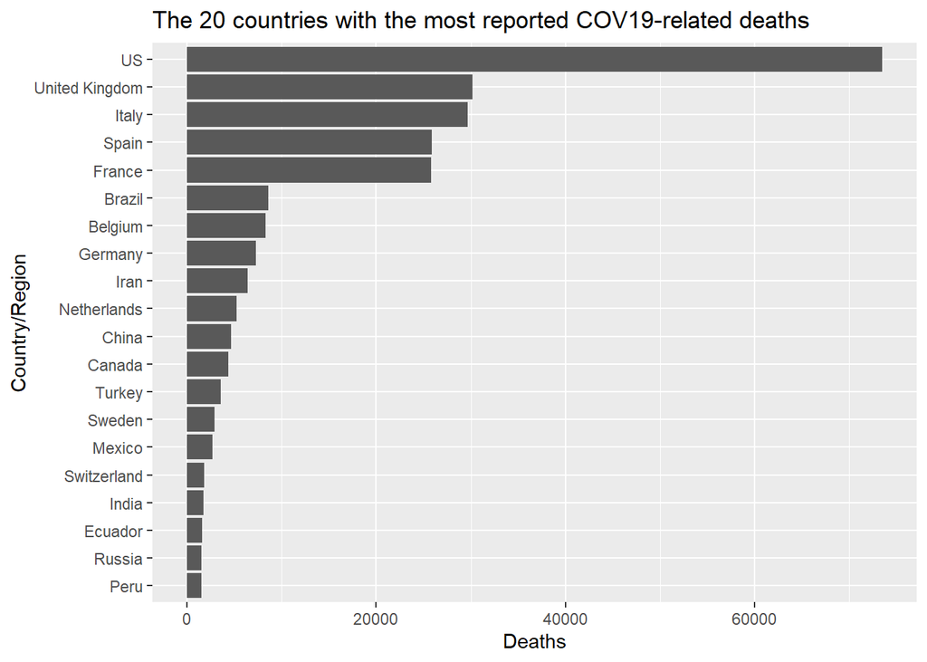

```r
report_05_06_2020 %>%
  group_by(Country_Region) %>%
  summarise(Deaths = sum(Deaths)) %>%
  arrange(desc(Deaths)) %>%
  slice(1:20) %>%
  ggplot(aes(x = Deaths,  y = reorder(Country_Region, Deaths))) +
    geom_bar(stat = 'identity') +
    ggtitle("The 20 countries with the most reported COV19-related deaths") +
    ylab("Country/Region") +
    xlab("Deaths")
```

### Working with the time series data

#### Data Wrangling

There is some data wrangling required for working with the time series data. As of March 26, 2020 it still used the old column headers so we need to rename them. I expect this will change soon.

Start by loading the most recent times series data for confirmed cases

```r
time_series_confirmed <- read_csv(url("https://raw.githubusercontent.com/CSSEGISandData/COVID-19/master/csse_covid_19_data/csse_covid_19_time_series/time_series_covid19_confirmed_global.csv")) %>%
  rename(Province_State = "Province/State", Country_Region = "Country/Region")
```

Check the table properties to make sure the data imported as we expected

```r
head(time_series_confirmed)
```

```
## # A tibble: 6 x 110
##   Province_State Country_Region   Lat   Long `1/22/20` `1/23/20` `1/24/20`
##   <chr>          <chr>          <dbl>  <dbl>     <dbl>     <dbl>     <dbl>
## 1 <NA>           Afghanistan     33    65            0         0         0
## 2 <NA>           Albania         41.2  20.2          0         0         0
## 3 <NA>           Algeria         28.0   1.66         0         0         0
## 4 <NA>           Andorra         42.5   1.52         0         0         0
## 5 <NA>           Angola         -11.2  17.9          0         0         0
## 6 <NA>           Antigua and B~  17.1 -61.8          0         0         0
## # ... with 103 more variables: `1/25/20` <dbl>, `1/26/20` <dbl>,
## #   `1/27/20` <dbl>, `1/28/20` <dbl>, `1/29/20` <dbl>, `1/30/20` <dbl>,
## #   `1/31/20` <dbl>, `2/1/20` <dbl>, `2/2/20` <dbl>, `2/3/20` <dbl>,
## #   `2/4/20` <dbl>, `2/5/20` <dbl>, `2/6/20` <dbl>, `2/7/20` <dbl>,
## #   `2/8/20` <dbl>, `2/9/20` <dbl>, `2/10/20` <dbl>, `2/11/20` <dbl>,
## #   `2/12/20` <dbl>, `2/13/20` <dbl>, `2/14/20` <dbl>, `2/15/20` <dbl>,
## #   `2/16/20` <dbl>, `2/17/20` <dbl>, `2/18/20` <dbl>, `2/19/20` <dbl>,
## #   `2/20/20` <dbl>, `2/21/20` <dbl>, `2/22/20` <dbl>, `2/23/20` <dbl>,
## #   `2/24/20` <dbl>, `2/25/20` <dbl>, `2/26/20` <dbl>, `2/27/20` <dbl>,
## #   `2/28/20` <dbl>, `2/29/20` <dbl>, `3/1/20` <dbl>, `3/2/20` <dbl>,
## #   `3/3/20` <dbl>, `3/4/20` <dbl>, `3/5/20` <dbl>, `3/6/20` <dbl>,
## #   `3/7/20` <dbl>, `3/8/20` <dbl>, `3/9/20` <dbl>, `3/10/20` <dbl>,
## #   `3/11/20` <dbl>, `3/12/20` <dbl>, `3/13/20` <dbl>, `3/14/20` <dbl>,
## #   `3/15/20` <dbl>, `3/16/20` <dbl>, `3/17/20` <dbl>, `3/18/20` <dbl>,
## #   `3/19/20` <dbl>, `3/20/20` <dbl>, `3/21/20` <dbl>, `3/22/20` <dbl>,
## #   `3/23/20` <dbl>, `3/24/20` <dbl>, `3/25/20` <dbl>, `3/26/20` <dbl>,
## #   `3/27/20` <dbl>, `3/28/20` <dbl>, `3/29/20` <dbl>, `3/30/20` <dbl>,
## #   `3/31/20` <dbl>, `4/1/20` <dbl>, `4/2/20` <dbl>, `4/3/20` <dbl>,
## #   `4/4/20` <dbl>, `4/5/20` <dbl>, `4/6/20` <dbl>, `4/7/20` <dbl>,
## #   `4/8/20` <dbl>, `4/9/20` <dbl>, `4/10/20` <dbl>, `4/11/20` <dbl>,
## #   `4/12/20` <dbl>, `4/13/20` <dbl>, `4/14/20` <dbl>, `4/15/20` <dbl>,
## #   `4/16/20` <dbl>, `4/17/20` <dbl>, `4/18/20` <dbl>, `4/19/20` <dbl>,
## #   `4/20/20` <dbl>, `4/21/20` <dbl>, `4/22/20` <dbl>, `4/23/20` <dbl>,
## #   `4/24/20` <dbl>, `4/25/20` <dbl>, `4/26/20` <dbl>, `4/27/20` <dbl>,
## #   `4/28/20` <dbl>, `4/29/20` <dbl>, `4/30/20` <dbl>, `5/1/20` <dbl>,
## #   `5/2/20` <dbl>, `5/3/20` <dbl>, ...
```

As noted above this data is in wide format. To convert to long format

```r
time_series_confirmed_long <- time_series_confirmed %>%
               pivot_longer(-c(Province_State, Country_Region, Lat, Long),
                            names_to = "Date", values_to = "Confirmed")
```

Let’s look at the format of the data frame (tibble) now

```r
head(time_series_confirmed_long)
```

```
## # A tibble: 6 x 6
##   Province_State Country_Region   Lat  Long Date    Confirmed
##   <chr>          <chr>          <dbl> <dbl> <chr>       <dbl>
## 1 <NA>           Afghanistan       33    65 1/22/20         0
## 2 <NA>           Afghanistan       33    65 1/23/20         0
## 3 <NA>           Afghanistan       33    65 1/24/20         0
## 4 <NA>           Afghanistan       33    65 1/25/20         0
## 5 <NA>           Afghanistan       33    65 1/26/20         0
## 6 <NA>           Afghanistan       33    65 1/27/20         0
```

It would be convenient to have the confirmed cases and deaths in the same table. We can create another table with the deaths and then join the two tables.

Let’s get the times series data for deaths

```r
time_series_deaths <- read_csv(url("https://raw.githubusercontent.com/CSSEGISandData/COVID-19/master/csse_covid_19_data/csse_covid_19_time_series/time_series_covid19_deaths_global.csv")) %>%
  rename(Province_State = "Province/State", Country_Region = "Country/Region")
```

and convert it to long format

```r
time_series_deaths_long <- time_series_deaths %>%
  pivot_longer(-c(Province_State, Country_Region, Lat, Long),
               names_to = "Date", values_to = "Deaths")
head(time_series_deaths_long)
```

```
## # A tibble: 6 x 6
##   Province_State Country_Region   Lat  Long Date    Deaths
##   <chr>          <chr>          <dbl> <dbl> <chr>    <dbl>
## 1 <NA>           Afghanistan       33    65 1/22/20      0
## 2 <NA>           Afghanistan       33    65 1/23/20      0
## 3 <NA>           Afghanistan       33    65 1/24/20      0
## 4 <NA>           Afghanistan       33    65 1/25/20      0
## 5 <NA>           Afghanistan       33    65 1/26/20      0
## 6 <NA>           Afghanistan       33    65 1/27/20      0
```

To join 2 tables we need a common column in which each row is a unique name. This is often called the Key. None of the columns in this data set meet that criteria, but we can create a column to serve as our key by mergering the names for the Province_State, Country_Region and Date columns using **unite**

```r
time_series_confirmed_long <- time_series_confirmed_long %>%
  unite(Key, Province_State, Country_Region, Date, sep = ".", remove = FALSE)
head(time_series_confirmed_long)
```

```
## # A tibble: 6 x 7
##   Key                 Province_State Country_Region   Lat  Long Date   Confirmed
##   <chr>               <chr>          <chr>          <dbl> <dbl> <chr>      <dbl>
## 1 NA.Afghanistan.1/2~ <NA>           Afghanistan       33    65 1/22/~         0
## 2 NA.Afghanistan.1/2~ <NA>           Afghanistan       33    65 1/23/~         0
## 3 NA.Afghanistan.1/2~ <NA>           Afghanistan       33    65 1/24/~         0
## 4 NA.Afghanistan.1/2~ <NA>           Afghanistan       33    65 1/25/~         0
## 5 NA.Afghanistan.1/2~ <NA>           Afghanistan       33    65 1/26/~         0
## 6 NA.Afghanistan.1/2~ <NA>           Afghanistan       33    65 1/27/~         0
```

For the second table we can do the same and eliminate the columns that are redundant so that we just have the Key and Deaths columns

```r
time_series_deaths_long <- time_series_deaths_long %>%
  unite(Key, Province_State, Country_Region, Date, sep = ".") %>%
  select(Key, Deaths)
```

Now to join the tables. A **full_join** which means that the keys that are common to the tables will be joined and there will be counts for both Confirmed and Deaths. Where there are not matching values, returns NA for the one missing. **select** can be used to remove the key after the join since we don’t have further need for it.

```r
time_series_long_joined <- full_join(time_series_confirmed_long,
              time_series_deaths_long, by = c("Key"))
head(time_series_long_joined)
```

```
## # A tibble: 6 x 8
##   Key           Province_State Country_Region   Lat  Long Date  Confirmed Deaths
##   <chr>         <chr>          <chr>          <dbl> <dbl> <chr>     <dbl>  <dbl>
## 1 NA.Afghanist~ <NA>           Afghanistan       33    65 1/22~         0      0
## 2 NA.Afghanist~ <NA>           Afghanistan       33    65 1/23~         0      0
## 3 NA.Afghanist~ <NA>           Afghanistan       33    65 1/24~         0      0
## 4 NA.Afghanist~ <NA>           Afghanistan       33    65 1/25~         0      0
## 5 NA.Afghanist~ <NA>           Afghanistan       33    65 1/26~         0      0
## 6 NA.Afghanist~ <NA>           Afghanistan       33    65 1/27~         0      0
```

Check to make sure neither the Cofirmed or Death counts have NA as a value (both tables have the same number of rows, but we should check to make sure)

```r
which(is.na(time_series_long_joined$Confirmed))
```

```
## integer(0)
```

```r
which(is.na(time_series_long_joined$Deaths))
```

```
## integer(0)
```

There are no NA values.

Following the same set of steps to add the Recovered Data

```r
### download the file
time_series_recovered <- read_csv(url("https://raw.githubusercontent.com/CSSEGISandData/COVID-19/master/csse_covid_19_data/csse_covid_19_time_series/time_series_covid19_recovered_global.csv")) %>%
  rename(Province_State = "Province/State", Country_Region = "Country/Region")

### convert to long format
time_series_recovered_long <- time_series_recovered %>%
  pivot_longer(-c(Province_State, Country_Region, Lat, Long),
               names_to = "Date", values_to = "Recovered")

### Create the Key
time_series_recovered_long <- time_series_recovered_long %>%
  unite(Key, Province_State, Country_Region, Date, sep = ".") %>%
  select(Key, Recovered)

### Merge with prior table (only this time will delete the Key column
### because we have no further use for it)
time_series_long_joined <- full_join(time_series_long_joined,
              time_series_recovered_long, by = c("Key")) %>%
    select(-Key)
head(time_series_long_joined)
```

```
## # A tibble: 6 x 8
##   Province_State Country_Region   Lat  Long Date    Confirmed Deaths Recovered
##   <chr>          <chr>          <dbl> <dbl> <chr>       <dbl>  <dbl>     <dbl>
## 1 <NA>           Afghanistan       33    65 1/22/20         0      0         0
## 2 <NA>           Afghanistan       33    65 1/23/20         0      0         0
## 3 <NA>           Afghanistan       33    65 1/24/20         0      0         0
## 4 <NA>           Afghanistan       33    65 1/25/20         0      0         0
## 5 <NA>           Afghanistan       33    65 1/26/20         0      0         0
## 6 <NA>           Afghanistan       33    65 1/27/20         0      0         0
```

Now we are in good shape to proceed to using these table for graphing, but first reformat Date

```r
time_series_long_joined$Date <- mdy(time_series_long_joined$Date)
```

Confirmed, Deaths and Recovered are all count data, and there may be times when we want to plot all three on the same graph. There are multiple ways to accomplish this and one is through creating a column will all 3 using _pivot_long

```r
time_series_long_joined_counts <- time_series_long_joined %>%
  pivot_longer(-c(Province_State, Country_Region, Lat, Long, Date),
               names_to = "Report_Type", values_to = "Counts")
head(time_series_long_joined_counts)
```

```
## # A tibble: 6 x 7
##   Province_State Country_Region   Lat  Long Date       Report_Type Counts
##   <chr>          <chr>          <dbl> <dbl> <date>     <chr>        <dbl>
## 1 <NA>           Afghanistan       33    65 2020-01-22 Confirmed        0
## 2 <NA>           Afghanistan       33    65 2020-01-22 Deaths           0
## 3 <NA>           Afghanistan       33    65 2020-01-22 Recovered        0
## 4 <NA>           Afghanistan       33    65 2020-01-23 Confirmed        0
## 5 <NA>           Afghanistan       33    65 2020-01-23 Deaths           0
## 6 <NA>           Afghanistan       33    65 2020-01-23 Recovered        0
```

#### Making Graphs from the time series data

To make a times series graph of the confirmed cases we need to summarize the Country date to count up the individual state data for the US.

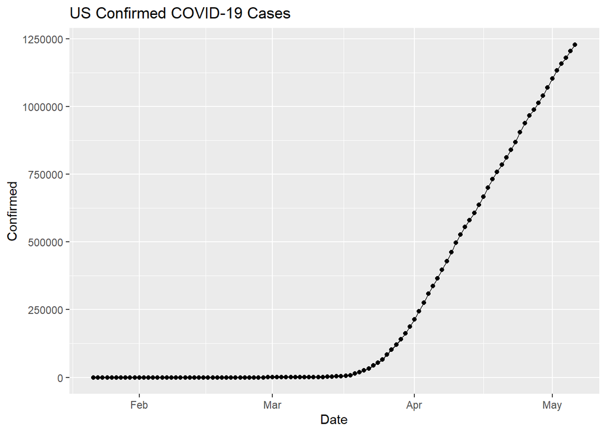

```r
time_series_long_joined %>%
  group_by(Country_Region,Date) %>%
  summarise_at(c("Confirmed", "Deaths", "Recovered"), sum) %>%
  filter (Country_Region == "US") %>%
    ggplot(aes(x = Date,  y = Confirmed)) +
    geom_point() +
    geom_line() +
    ggtitle("US Confirmed COVID-19 Cases")
```

Let’s look at the US data in the context of a few other countries

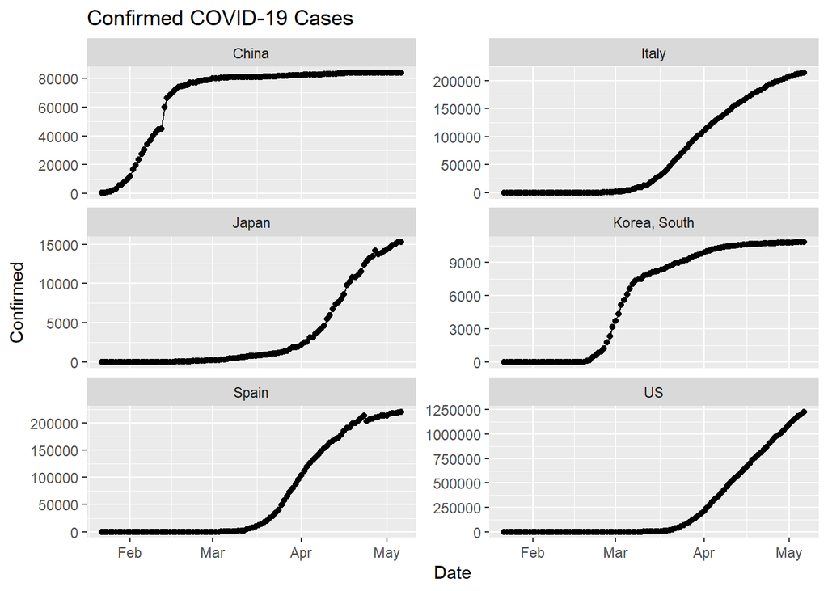

```r
time_series_long_joined %>%
  group_by(Country_Region,Date) %>%
  summarise_at(c("Confirmed", "Deaths", "Recovered"), sum) %>%
  filter (Country_Region %in% c("China","Japan", "Korea, South",
                                "Italy","Spain", "US")) %>%
    ggplot(aes(x = Date,  y = Confirmed)) +
    geom_point() +
    geom_line() +
    ggtitle("Confirmed COVID-19 Cases") +
    facet_wrap(~Country_Region, ncol=2, scales="free_y")
```

Now several countries on the same graph

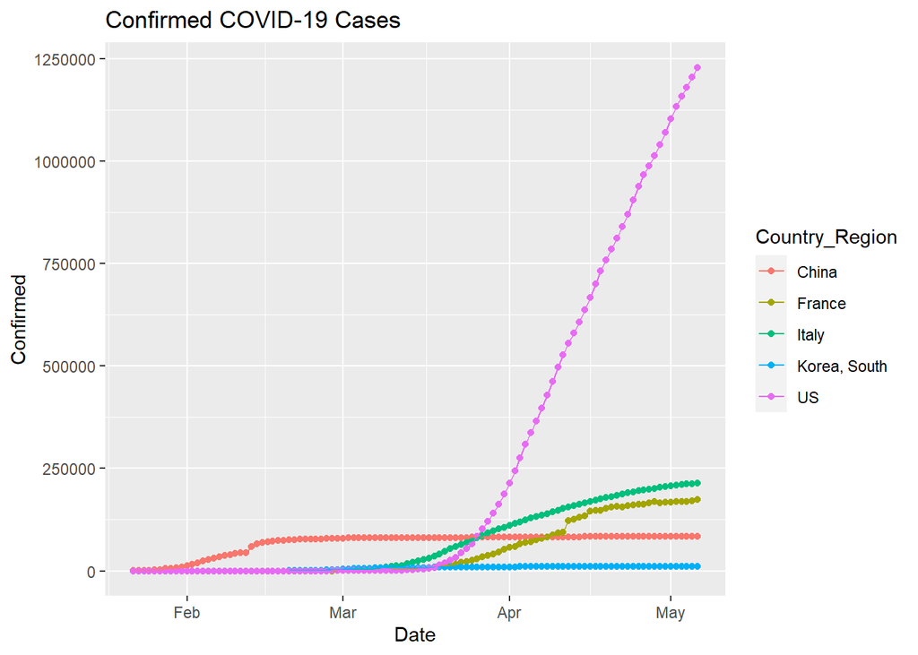

```r
time_series_long_joined %>%
    group_by(Country_Region,Date) %>%
    summarise_at(c("Confirmed", "Deaths", "Recovered"), sum) %>%
    filter (Country_Region %in% c("China","France","Italy",
                                "Korea, South", "US")) %>%
    ggplot(aes(x = Date,  y = Confirmed, color = Country_Region)) +
    geom_point() +
    geom_line() +
    ggtitle("Confirmed COVID-19 Cases")
```

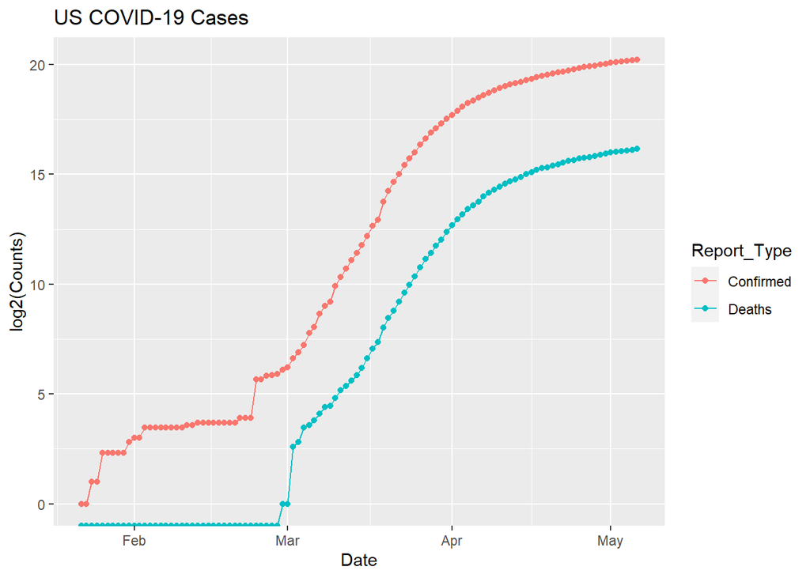

```r
time_series_long_joined_counts %>%
  group_by(Country_Region, Report_Type, Date) %>%
  summarise(Counts = sum(Counts)) %>%
  filter (Country_Region == "US") %>%
  filter (Report_Type %in% c("Confirmed", "Deaths")) %>%
    ggplot(aes(x = Date,  y = log2(Counts), fill = Report_Type, color = Report_Type)) +
    geom_point() +
    geom_line() +
    ggtitle("US COVID-19 Cases")
```

### Visualizing data on maps

Here are two examples provided by Prof. Chris Sutherland and Anisa Dhana. They both rely on using the **maps** package. For ideas on how to build on these examples here is a nice tutorial on Maps in R using [maps](https://cran.r-project.org/web/packages/maps/maps.pdf) by [Eric Anderson](http://eriqande.github.io/rep-res-web/lectures/making-maps-with-R.html)

#### Adaptation of a post from Anisa Dhana on [R-Bloggers](https://www.r-bloggers.com/map-visualization-of-covid-19-across-the-world-with-r/)

- This code uses data is in wide format from the above times series.

Load the additional libraries (and install if necessary)

```r
library(maps)
library(viridis)
```

Get the world map

```r
world <- map_data("world")
```

Cutoffs based on the number of cases

```r
mybreaks <- c(1, 20, 100, 1000, 50000)
```

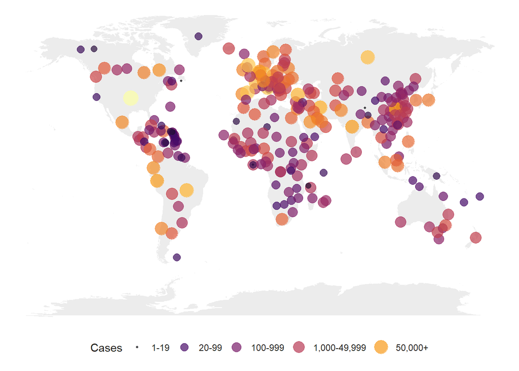

```r
ggplot() +
  geom_polygon(data = world, aes(x=long, y = lat, group = group), fill="grey", alpha=0.3) +
  geom_point(data=time_series_confirmed, aes(x=Long, y=Lat, size=`5/5/20`, color=`5/5/20`),stroke=F, alpha=0.7) +
  scale_size_continuous(name="Cases", trans="log", range=c(1,7),breaks=mybreaks, labels = c("1-19", "20-99", "100-999", "1,000-49,999", "50,000+")) +
  # scale_alpha_continuous(name="Cases", trans="log", range=c(0.1, 0.9),breaks=mybreaks) +
  scale_color_viridis_c(option="inferno",name="Cases", trans="log",breaks=mybreaks, labels = c("1-19", "20-99", "100-999", "1,000-49,999", "50,000+")) +
  theme_void() +
  guides( colour = guide_legend()) +
  labs(caption = "") +
  theme(
    legend.position = "bottom",
    text = element_text(color = "#22211d"),
    plot.background = element_rect(fill = "#ffffff", color = NA),
    panel.background = element_rect(fill = "#ffffff", color = NA),
    legend.background = element_rect(fill = "#ffffff", color = NA)
  )
```

#### Adaptation of code from Prof. Chris Sutherland

Get data, pivot to longer format, mutate and summarize

```r
time_series_confirmed_long2 <- read_csv(url("https://raw.githubusercontent.com/CSSEGISandData/COVID-19/master/csse_covid_19_data/csse_covid_19_time_series/time_series_covid19_confirmed_global.csv")) %>%
    rename(Province_State = "Province/State", Country_Region = "Country/Region") %>%
    pivot_longer(-c(Province_State, Country_Region, Lat, Long),
    names_to = "Date", values_to = "cumulative_cases") %>%
    mutate(Date = mdy(Date) - days(1),
        Place = paste(Lat,Long,sep="_")) %>%
    group_by(Place,Date) %>%
        summarise(cumulative_cases = ifelse(sum(cumulative_cases)>0,
        sum(cumulative_cases),NA_real_),
        Lat = mean(Lat),
        Long = mean(Long)) %>%
    mutate(Pandemic_day = as.numeric(Date - min(Date)))
```

View the table

```r
head(time_series_confirmed_long2)
```

```
## # A tibble: 6 x 6
## # Groups:   Place [1]
##   Place           Date       cumulative_cases     Lat  Long Pandemic_day
##   <chr>           <date>                <dbl>   <dbl> <dbl>        <dbl>
## 1 -0.0236_37.9062 2020-01-21               NA -0.0236  37.9            0
## 2 -0.0236_37.9062 2020-01-22               NA -0.0236  37.9            1
## 3 -0.0236_37.9062 2020-01-23               NA -0.0236  37.9            2
## 4 -0.0236_37.9062 2020-01-24               NA -0.0236  37.9            3
## 5 -0.0236_37.9062 2020-01-25               NA -0.0236  37.9            4
## 6 -0.0236_37.9062 2020-01-26               NA -0.0236  37.9            5
```

Plot the data

[figure not shown]

```r
static <- ggplot(subset(time_series_confirmed_long2,Date %in% seq(min(Date),max(Date),14)),
            aes(x = Long, y = Lat, size = cumulative_cases/1000)) +
            borders("world", colour = NA, fill = "grey90") +
            theme_bw() +
            geom_point(shape = 21, color='purple', fill='purple', alpha = 0.5) +
            labs(title = 'COVID-19 spread',x = '', y = '',
                 size="Cases (x1000))") +
            theme(legend.position = "right") +
            coord_fixed(ratio=1)+
            facet_wrap(.~Date,ncol=1)
static
```

# Exercises

The above graphs are minimal and meant to provide some starter code. I am sure you can make these richer and with greater impact. Create at least 2 new graphs (different from the ones above) each from the categories of daily reports, time series and geographical maps that best convey aspects of the pandemic relevant to you.

Submit this exercise as a link from your Github page (Submit your Github website URL in Moodle).

```r
time_series_long_joined_counts_sum <- time_series_long_joined_counts %>%
  group_by(Country_Region, Report_Type, Date) %>%
  summarise(Counts = log2(sum(Counts))) %>%
  filter (Country_Region == "US") %>%
  filter (Report_Type %in% c("Confirmed"))
```

```r
library(forecast)
```

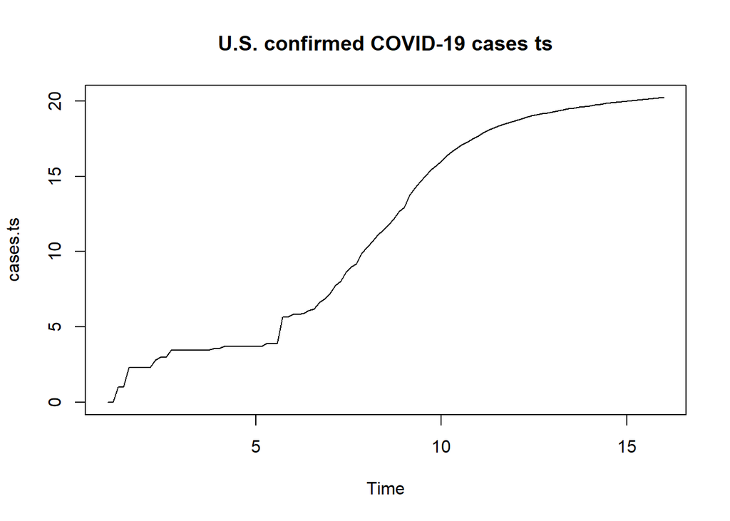

```r
cases <- time_series_long_joined_counts_sum$Counts
cases.ts <- ts(cases, frequency=7)
plot(cases.ts)
title("U.S. confirmed COVID-19 cases ts")
```

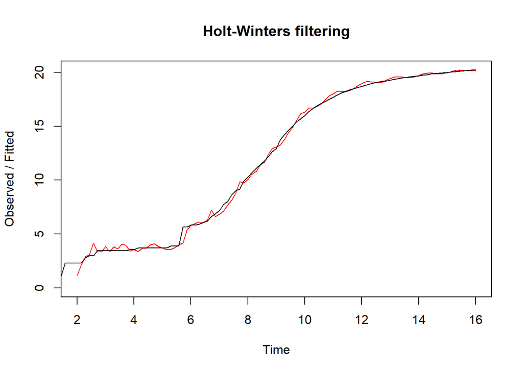

```r
HW.fit <- HoltWinters(cases.ts)
plot(HW.fit)
```

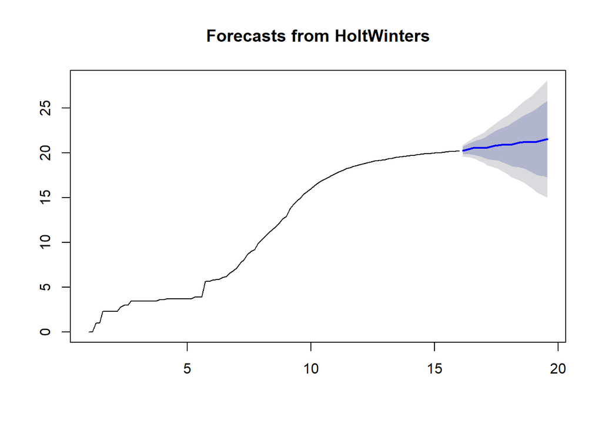

```r
HW.pred <- forecast:::forecast.HoltWinters(HW.fit, h=25)
forecast:::plot.forecast(HW.pred)
```

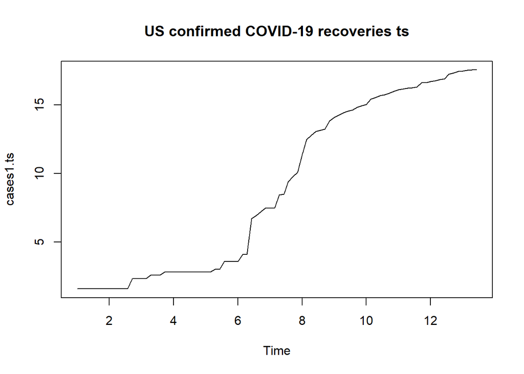

```r
time_series_long_joined_counts_recovered_sum <- time_series_long_joined_counts %>%
  group_by(Country_Region, Report_Type, Date) %>%
  filter(Counts != 0) %>%
  summarise(Counts = log2(sum(Counts))) %>%
  filter (Country_Region == "US") %>%
  filter (Report_Type %in% c("Recovered"))
cases1 <- time_series_long_joined_counts_recovered_sum$Counts
cases1.ts <- ts(cases1, frequency=7)
plot(cases1.ts)
title("US confirmed COVID-19 recoveries ts")
```

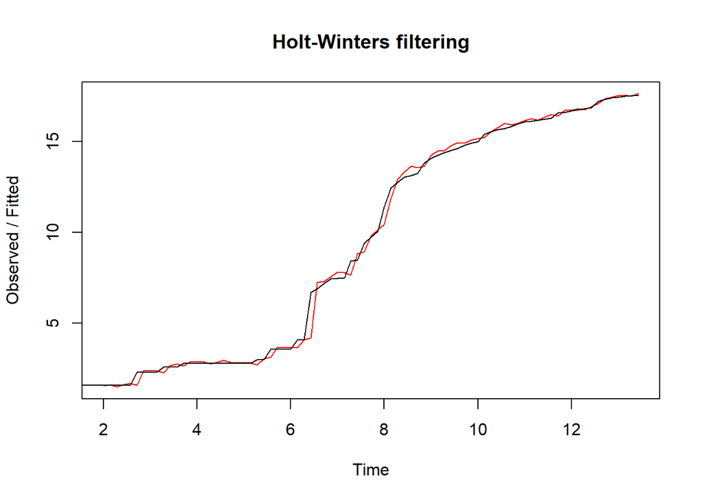

```r
HW.fit1 <- HoltWinters(cases1.ts)
plot(HW.fit1)
```

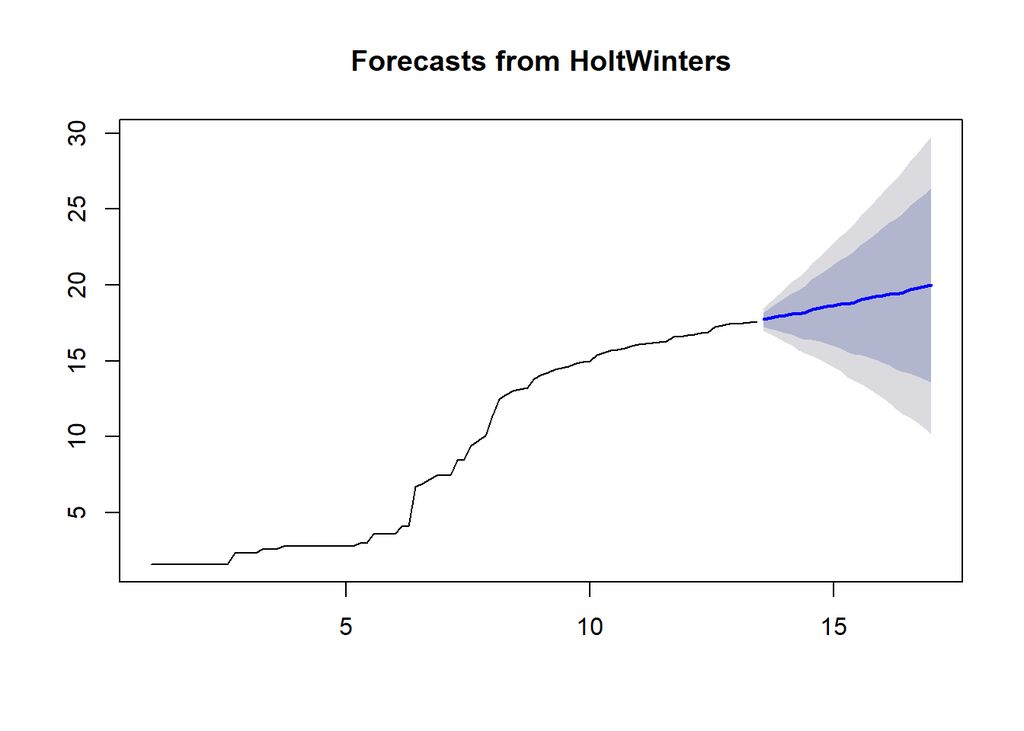

```r
HW.pred1 <- forecast:::forecast.HoltWinters(HW.fit1, h=25)
forecast:::plot.forecast(HW.pred1)
```

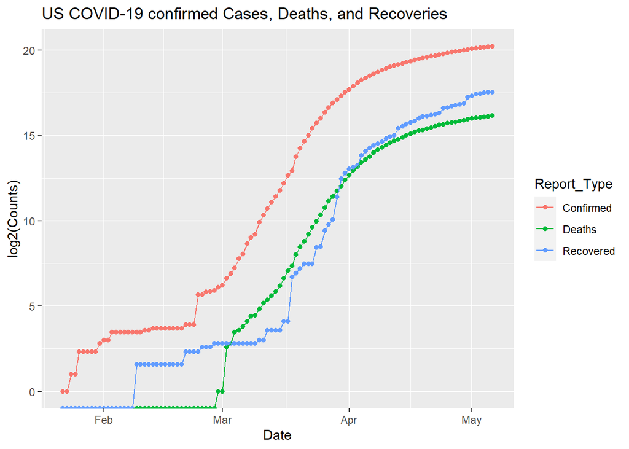

```r
time_series_long_joined_counts %>%
  group_by(Country_Region, Report_Type, Date) %>%
  summarise(Counts = sum(Counts)) %>%
  filter (Country_Region == "US") %>%
  filter (Report_Type %in% c("Confirmed", "Deaths", "Recovered")) %>%
    ggplot(aes(x = Date,  y = log2(Counts), fill = Report_Type, color = Report_Type)) +
    geom_point() +
    geom_line() +
    ggtitle("US COVID-19 confirmed Cases, Deaths, and Recoveries")
```

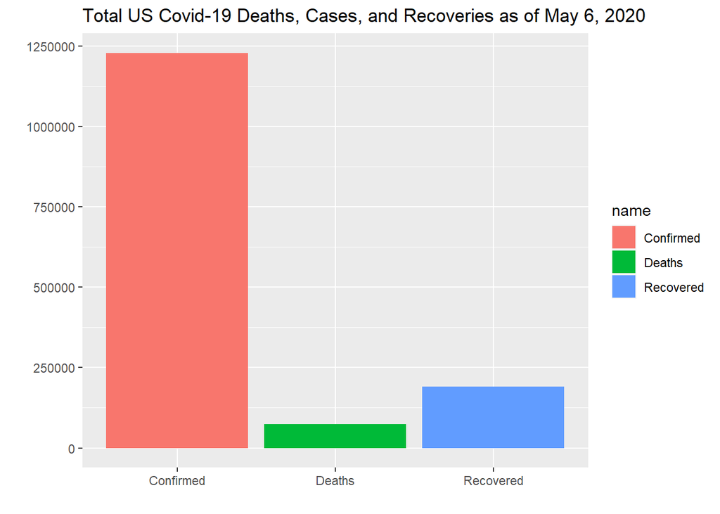

```r
report_05_06_2020 %>%
  filter(Country_Region == "US") %>%
  summarise(Deaths = sum(Deaths), Recovered = sum(Recovered), Confirmed = sum(Confirmed)) %>%
  pivot_longer(cols=c("Deaths", "Recovered", "Confirmed")) %>%

  ggplot(aes(x = name,  y = value, fill=name)) +
    geom_bar(stat = 'identity') +
    ggtitle("Total US Covid-19 Deaths, Cases, and Recoveries as of May 6, 2020") +
    ylab("") +
    xlab("")
```